# Final Project

柯曉攸 英語115 41121123L

## Objectives

Coldplay's music has resonated with audiences worldwide, offering emotional support through its lyrics. This project aims to explore the theme of hope in Coldplay's song lyrics by identifying and analyzing keywords related to hope. Using text analysis techniques, I will visualize the most frequently used hope-related keywords through a bar chart to illustrate how the band conveys messages of optimism and encouragement in their music.

## Pseudocode

Import all the required modules.

Read the text file.

Convert all text to lowercase. Remove punctuation and special characters. Tokenize the lyrics into individual words.

Create a list of keywords related to hope.

Filter the lyrics for the hope-related keywords.

Count the frequency of each keyword.

Plot a bar chart showing the frequency of hope-related keywords.

## Import Modules

```python
import pandas as pd
import matplotlib.pyplot as plt
from collections import Counter
import re
```

## Code

```python
# Read the file
with open("lyrics.txt", "r") as f:
    lyrics = f.read()
```

```python
# Convert to lowercase
lyrics = lyrics.lower()

# Remove special characters and numbers
lyrics = re.sub(r"[^a-z\s]", "", lyrics)

# split into words
words = lyrics.split()
```

```python
# List of hope-related keywords
hope_keywords = ["hope", "light", "dream", "future", "believe", "love", "faith", "better", "expect", "wish", "trust" ]
```

```python
# Count keyword frequencies
word_counts = Counter(words)
hope_counts = {word: word_counts[word] for word in hope_keywords if word in word_counts}
```

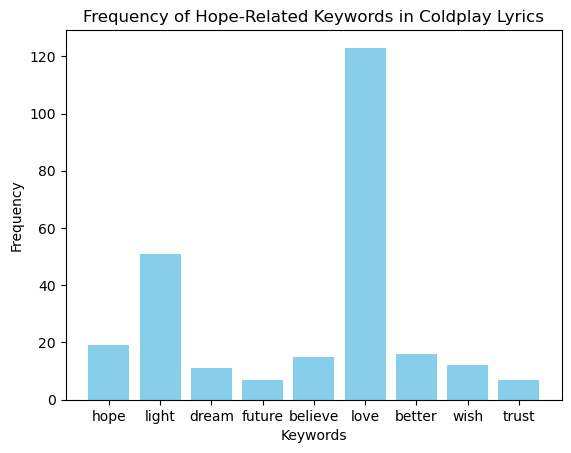

```python
# Plot bar chart
plt.bar(hope_counts.keys(), hope_counts.values(), color="skyblue")
plt.title("Frequency of Hope-Related Keywords in Coldplay Lyrics")
plt.xlabel("Keywords")
plt.ylabel("Frequency")
plt.show()
```